# Starter Dashboard

## Where this fits

You named the three pathways on dash01 and applied the 1-1-1-1-1 rule on dash02. This page is the **required core artifact** for Week 8: the Quarto-rendered dashboard-style page you will adapt for Assignment 7. The Shiny exemplar discussed on dash05 is a demonstration only — your A7 deliverable is built from the file on this page, not from the Shiny app.

## Goal

This starter shows how to turn the Week 7 descriptive summary into a dashboard-style KT product. It uses one editable control value, one visualization, one table, one interpretation, and one caution — the 1-1-1-1-1 rule made concrete.

## Audience Question

Audience: a public-health analyst preparing a short briefing on descriptive BMI patterns in the classroom NHANES equity dataset.

Question: among adults age 20-80, how does mean BMI vary across NHANES cycles for one selected income group?

## Setup

```r
library(tidyverse)  # AI-EDIT(2026-06-23): tidyverse-default — consolidated core library() calls into library(tidyverse)
library(knitr)

candidate_paths <- c(
  "examples/nhanes-equity/data/nhanes_equity_v6.csv",
  "../../examples/nhanes-equity/data/nhanes_equity_v6.csv"
)

data_path <- candidate_paths[file.exists(candidate_paths)][1]
if (is.na(data_path)) {
  stop("Could not find examples/nhanes-equity/data/nhanes_equity_v6.csv")
}

nhanes <- read_csv(data_path, show_col_types = FALSE)
```

## Control

In a Shiny app, this would become a dropdown. In this static starter, change the value of `selected_income` and render again.

```r
available_income_groups <- sort(unique(na.omit(nhanes$IncomeGroup)))
selected_income <- "Low Income (<1.3)"

if (!selected_income %in% available_income_groups) {
  selected_income <- available_income_groups[1]
}

selected_income
```

```
#> [1] "Low Income (<1.3)"
```

## Summary

```r
dashboard_summary <- nhanes |>
  filter(
    Age >= 20,
    Age <= 80,
    IncomeGroup == selected_income,
    !is.na(BMI),
    !is.na(Cycle)
  ) |>
  group_by(Cycle) |>
  summarise(
    n = n(),
    mean_bmi = round(mean(BMI), 1),
    .groups = "drop"
  )

kable(dashboard_summary)
```

| Cycle | n | mean_bmi |
| --- | --- | --- |
| 1999-2000 | 1091 | 28.8 |
| 2001-2002 | 1089 | 28.7 |
| 2003-2004 | 1183 | 28.6 |
| 2005-2006 | 1091 | 29.3 |
| 2007-2008 | 1552 | 29.1 |
| 2009-2010 | 1817 | 29.5 |
| 2011-2012 | 1724 | 29.4 |
| 2013-2014 | 1762 | 29.5 |
| 2015-2016 | 1568 | 30.0 |
| 2017-2018 | 1275 | 30.1 |
| 2021-2023 | 1141 | 30.4 |

## Visualization

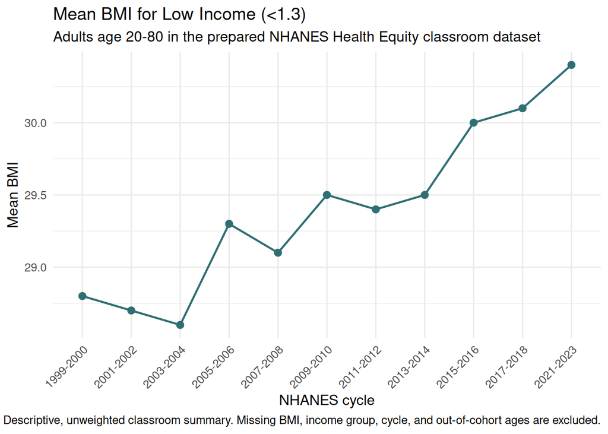

```r
ggplot(dashboard_summary, aes(x = Cycle, y = mean_bmi, group = 1)) +
  geom_line(linewidth = 0.8, color = "#2f6f73") +
  geom_point(size = 2.4, color = "#2f6f73") +
  labs(
    title = paste("Mean BMI for", selected_income),
    subtitle = "Adults age 20-80 in the prepared NHANES Health Equity classroom dataset",
    x = "NHANES cycle",
    y = "Mean BMI",
    caption = "Descriptive, unweighted classroom summary. Missing BMI, income group, cycle, and out-of-cohort ages are excluded."
  ) +
  theme_minimal(base_size = 12) +
  theme(axis.text.x = element_text(angle = 45, hjust = 1))
```

## Interpretation

For the selected income group, the table and figure describe the mean BMI pattern across available NHANES cycles in the prepared classroom dataset. The dashboard should help the audience ask better questions about pattern, timing, and context rather than treat the line as a causal explanation.

## Limitation

This starter is unweighted and descriptive. It does not account for NHANES survey design, does not estimate national prevalence, and should not be used to make causal claims about income and BMI.

## Testing

Before submitting a dashboard-style product:

1. Render this page from the repository root.
2. Change `selected_income` to another value from `available_income_groups`.
3. Render again and check that the table, title, and plot all update.
4. Verify that the caption still names the dataset, exclusions, and limitation.
5. Record any warning or error in your testing log.

**TipHow to render: the course default**

1. Save the `.qmd` file you want to render, then open the **Command Palette** (**View → Command Palette**, or press **Ctrl+Shift+P** on Windows/Linux / **Cmd+Shift+P** on Mac) and run **Quarto: Render Document**. When a menu asks which format, choose **Render HTML** (or **Render PDF (Typst)** for a PDF).
2. **Always-works fallback (terminal):** type the render command with the file’s path as shown in the Explorer, for example:

   ```bash
   quarto render practice_report.qmd
   ```

   Always name the file — a bare `quarto render` rebuilds the *whole* project and takes much longer.
3. The **Preview** button at the top-right of the editor renders too, in the format the file asks for, without the menu.

**Where did the output go?** Watch the render log for the `Output created:` line — it names the exact file created. By default the file appears next to your `.qmd`; in projects that set an output directory (like this book’s `docs/` folder), it appears there instead.

**To look at it,** click the file in the Explorer: an `.html` or `.pdf` opens in a tab inside VS Code. After you render again, close that tab and click the file again. To open it in your own browser instead (for example, slides to present full screen, or a page to print), right-click it and choose **Download**.

## Privacy-Safe Publishing

- Use aggregate summaries, not row-level records.
- Avoid small-cell interpretations when `n` is low.
- State that outputs are descriptive and unweighted.
- Keep cached classroom data separate from any raw NHANES retrieval workflow.
- Do not upload row-level data to external AI tools.

## Where this goes next

dash04 shows what counts as an audience-facing text change (allowed) versus an analytic change (not allowed for A7). dash05 walks through how to test this page in Codespaces and shows the optional Shiny exemplar that your instructor will demo in class.